# Diving into `ggplot2`

Instructor - Soumya Mukherjee

Content Credit- Dr. Matthew Beckman and Olivia Beck

July 19, 2023

## Agenda

- brief introduction to `::`
- `ggplot()` flyover
- remarks about facets
- `color` vs. `fill`

## PackageName::FunctionName

- We can use the `::` function to reference functions inside packages.
  - This helps us be extra sure that we are using the exact function we want to be
  - Helps avoid conflict (i.e. when 2 packages that have a function with the same name that do different things)

```r
library(tidyverse)
head(diamonds)
```

| carat | cut | color | clarity | depth | table | price | x | y | z |
| --- | --- | --- | --- | --- | --- | --- | --- | --- | --- |
| 0.23 | Ideal | E | SI2 | 61.5 | 55 | 326 | 3.95 | 3.98 | 2.43 |
| 0.21 | Premium | E | SI1 | 59.8 | 61 | 326 | 3.89 | 3.84 | 2.31 |
| 0.23 | Good | E | VS1 | 56.9 | 65 | 327 | 4.05 | 4.07 | 2.31 |
| 0.29 | Premium | I | VS2 | 62.4 | 58 | 334 | 4.20 | 4.23 | 2.63 |
| 0.31 | Good | J | SI2 | 63.3 | 58 | 335 | 4.34 | 4.35 | 2.75 |
| 0.24 | Very Good | J | VVS2 | 62.8 | 57 | 336 | 3.94 | 3.96 | 2.48 |

```r
#?filter

#filter from dplyr
diamonds %>%
  dplyr::filter(color == "E") %>%
  head()
```

| carat | cut | color | clarity | depth | table | price | x | y | z |
| --- | --- | --- | --- | --- | --- | --- | --- | --- | --- |
| 0.23 | Ideal | E | SI2 | 61.5 | 55 | 326 | 3.95 | 3.98 | 2.43 |
| 0.21 | Premium | E | SI1 | 59.8 | 61 | 326 | 3.89 | 3.84 | 2.31 |
| 0.23 | Good | E | VS1 | 56.9 | 65 | 327 | 4.05 | 4.07 | 2.31 |
| 0.22 | Fair | E | VS2 | 65.1 | 61 | 337 | 3.87 | 3.78 | 2.49 |
| 0.20 | Premium | E | SI2 | 60.2 | 62 | 345 | 3.79 | 3.75 | 2.27 |
| 0.32 | Premium | E | I1 | 60.9 | 58 | 345 | 4.38 | 4.42 | 2.68 |

```r
#normal
diamonds %>%
  filter(color == "E") %>%
  head()
```

| carat | cut | color | clarity | depth | table | price | x | y | z |
| --- | --- | --- | --- | --- | --- | --- | --- | --- | --- |
| 0.23 | Ideal | E | SI2 | 61.5 | 55 | 326 | 3.95 | 3.98 | 2.43 |
| 0.21 | Premium | E | SI1 | 59.8 | 61 | 326 | 3.89 | 3.84 | 2.31 |
| 0.23 | Good | E | VS1 | 56.9 | 65 | 327 | 4.05 | 4.07 | 2.31 |
| 0.22 | Fair | E | VS2 | 65.1 | 61 | 337 | 3.87 | 3.78 | 2.49 |
| 0.20 | Premium | E | SI2 | 60.2 | 62 | 345 | 3.79 | 3.75 | 2.27 |
| 0.32 | Premium | E | I1 | 60.9 | 58 | 345 | 4.38 | 4.42 | 2.68 |

```r
NA
```

## Building Graphics

1. Draw by hand (or imagine) the specific plot that you intend to construct
2. Data Wrangling (if needed) to get the data in glyph-ready form, or verify that the current form is glyph-ready for your purposes.
3. Establish the frame using a `ggplot()` statement
4. Create the intended glyph using `geom_[style]()` such as
   - `geom_point()`
   - `geom_bar()`
   - `geom_boxplot()`
   - `geom_density()`
   - `geom_vline()`
   - `geom_segment()`
   - `geom_histogram()`
   - and *many* more
5. Map variables to the graphical attributes of the glyph using: `aes( )`
- Rule of thumb: anytime when you are plotting with ggplot, ALL variables need to be inside an `aes` (except facets, later in slides).
6. Add additional layers to the frame using the `+` symbol
   - Note: **not** `%>%` between layers of `ggplot2` graphics
   - Maybe think “add layer” in `ggplot2` portions, instead of “and then” with `%>%` syntax

*Steps 4 and 5 can be switched.*

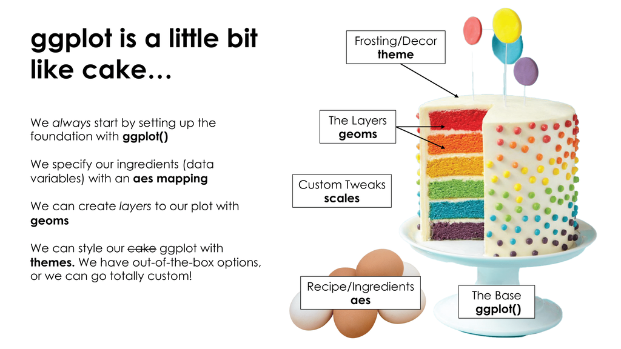

https://twitter.com/tanya_shapiro/status/1576935152575340544?t=vwaW8h6CC62h0pkwv9n5Yg&s=19

## Example: Baby Names

Let’s look at our `BabyNames` names data set agian.

```r
# data intake
data("BabyNames", package = "dcData")

# inspect data intake
glimpse(BabyNames)
```

```
Rows: 1,792,091
Columns: 4
$ name  <chr> "Mary", "Anna", "Emma", "Elizabeth", "M…
$ sex   <chr> "F", "F", "F", "F", "F", "F", "F", "F",…
$ count <int> 7065, 2604, 2003, 1939, 1746, 1578, 147…
$ year  <int> 1880, 1880, 1880, 1880, 1880, 1880, 188…
```

## wrangle into glyph-ready form

```r
names <- c("Olivia", "Zoe", "Quentin")

Names <-
  BabyNames %>%
  filter(name %in% names) %>%
  group_by(name, year) %>%
  summarise(total = sum(count, na.rm = TRUE))
Names %>%
  head()
```

| name | year | total |
| --- | --- | --- |
| Olivia | 1880 | 44 |
| Olivia | 1881 | 51 |
| Olivia | 1882 | 52 |
| Olivia | 1883 | 46 |
| Olivia | 1884 | 54 |
| Olivia | 1885 | 59 |

```r
NA
```

## in the beginning you might use esquisser to get started–here’s the default result

This isn’t easy to read, and it’s in bad form.

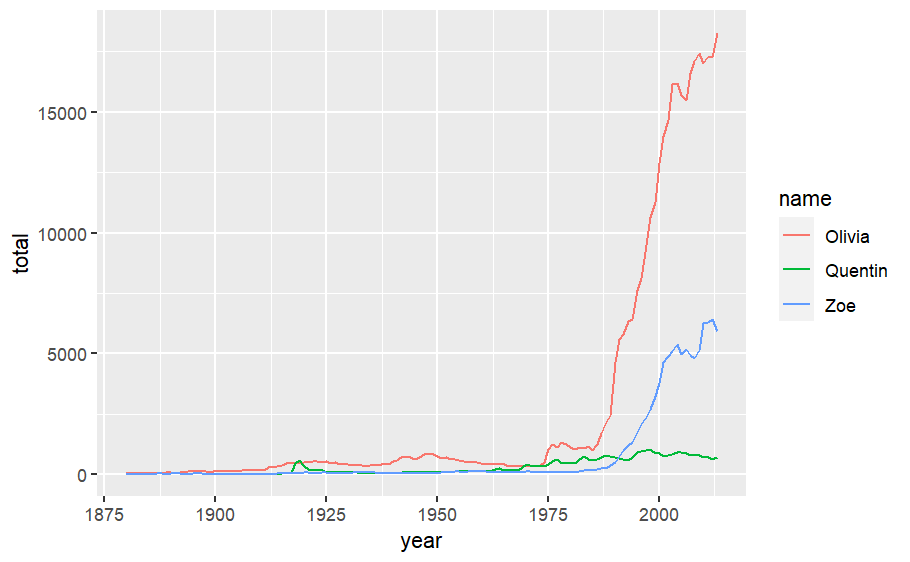

```r
# esquisser(Names)
# ggplot(data = Names, aes(x = year, y = total)) + geom_line()  + aes(colour = name) + theme(legend.position = "right") + labs(title = "")
ggplot(Names) +
  aes(x = year, y = total, colour = name) +
  geom_line() +
  scale_color_hue(direction = 1) +
  theme_gray()
```

## we can do better

1. establish the frame
2. plot the glyphs (i.e., select a geom)
3. map the aesthetics
4. add labels and title
5. other features (e.g., alpha, sizing, etc)

#### Our Plot

1. Establish the Frame

Nothing is here! That is exactly what is supposed to happen. Calling `ggplot()` only tells us R that we are ready to plot and I want to call some space to create my plot.

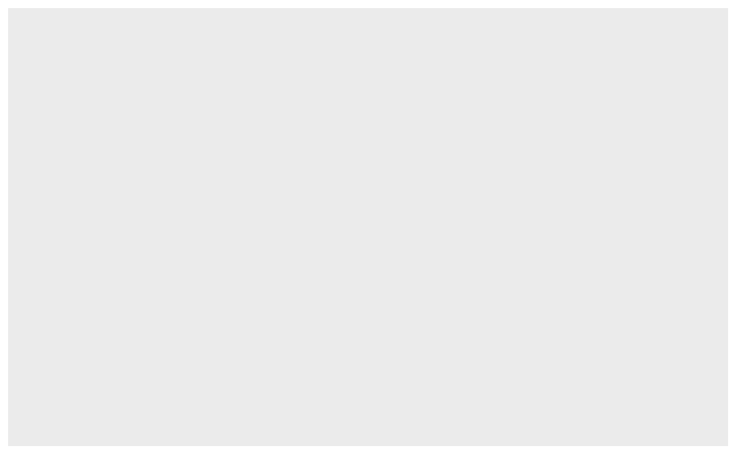

```r
ggplot(data = Names)
```

```r
NA
```

2. plot the glyphs (i.e., select a geom)

Still Nothing! We need to tell it what our axis are.

Note that ggplot uses `+`, NOT `%>%`. This is because we are **adding** layers to our plots.

```r
ggplot(data = Names) +
  geom_line()
```

```
Error in `geom_line()`:
! Problem while setting up geom.
ℹ Error occurred in the 1st layer.
Caused by error in `compute_geom_1()`:
! `geom_line()` requires the following missing
  aesthetics: x and y
Backtrace:
  1. base (local) `<fn>`(x)
  2. ggplot2:::print.ggplot(x)
  4. ggplot2:::ggplot_build.ggplot(x)
  5. ggplot2:::by_layer(...)
 12. ggplot2 (local) f(l = layers[[i]], d = data[[i]])
 13. l$compute_geom_1(d)
 14. ggplot2 (local) compute_geom_1(..., self = self)
```

Note - this is why I like to map aesthetics first, so we can avoid errors.

3. Map the aesthetics

Rule of thumb: anytime when you are plotting with ggplot, ALL variables need to be inside an `aes` (except facets, later in slides).

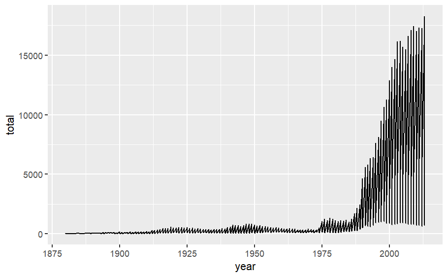

```r
#not Quite
ggplot(data = Names) +
  geom_line( aes(x = year, y = total))
```

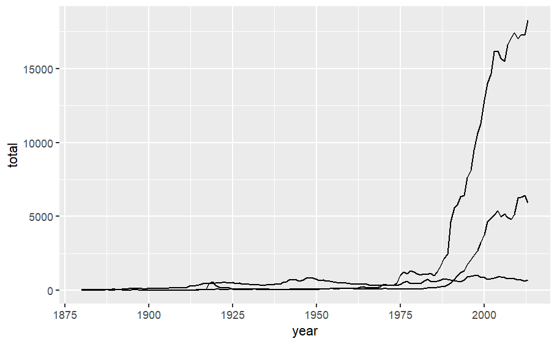

```r
#add groups
ggplot(data = Names) +
  geom_line( aes(x = year, y = total, group = name))
```

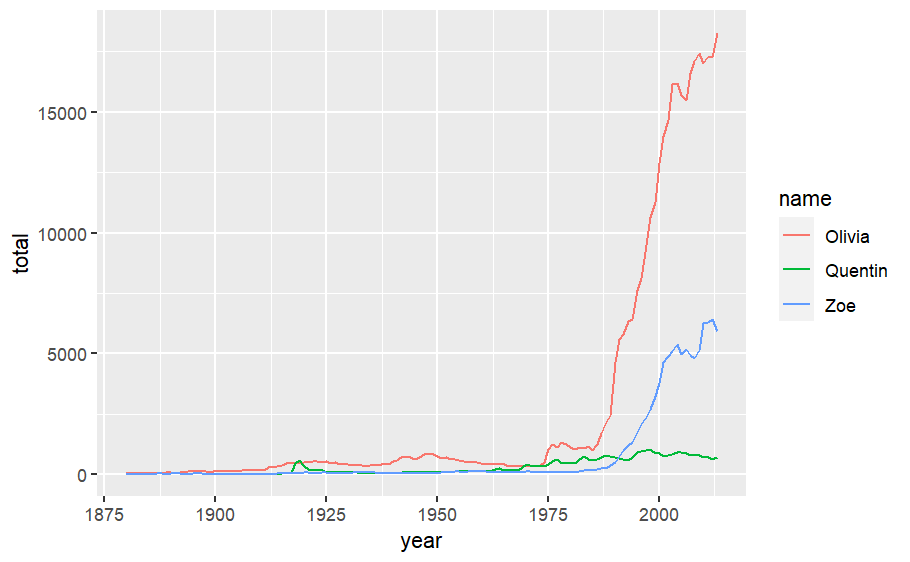

```r
#add color
ggplot(data = Names) +
  geom_line( aes(x = year, y = total, color = name))
```

```r
NA
NA
```

4. Add labels and title

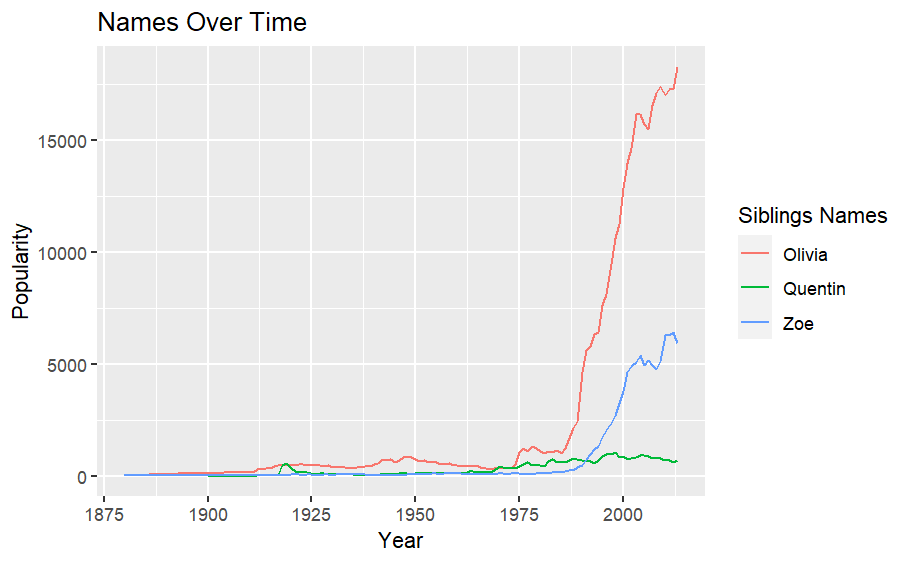

```r
ggplot(data = Names) +
  geom_line( aes(x = year, y = total, color = name)) +
  ggtitle("Names Over Time") +
  xlab("Year") +
  ylab("Popularity") +
  guides(color = guide_legend(title = "Siblings Names" ))
```

```r
NA
NA
```

5. other features (e.g., alpha, sizing, etc)

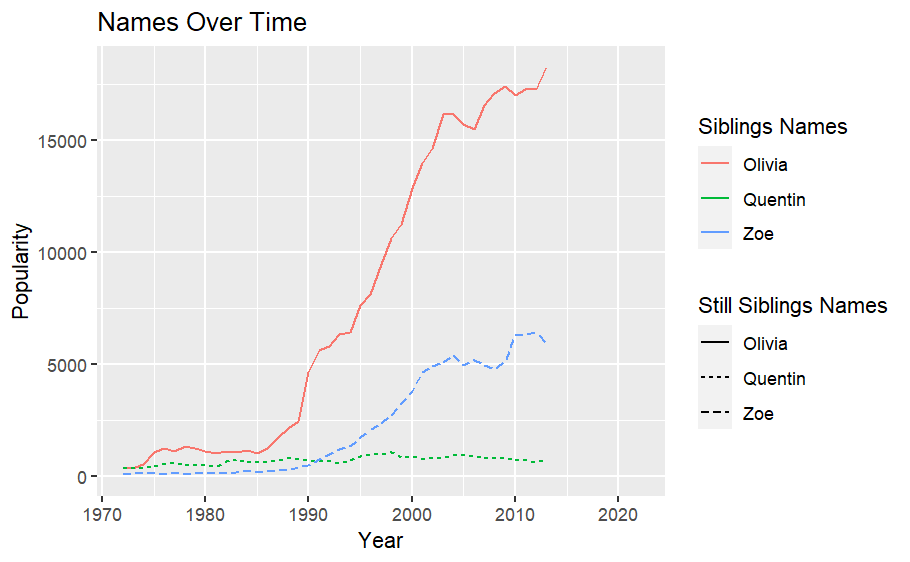

```r
ggplot(data = Names) +
  geom_line( aes(x = year, y = total, color = name, linetype = name)) +
  ggtitle("Names Over Time") +
  xlim(c(1972, 2022))+
  xlab("Year") +
  ylab("Popularity") +
  guides(color = guide_legend(title = "Siblings Names" ),
         linetype = guide_legend(title = "Still Siblings Names" ))
```

```r
NA
NA
```

## Remarks about faceting: `facet_wrap()`

The syntax for facets requires a formula syntax we haven’t seen much yet. Also, there are two main ways to plot with facets. Here are a few pointers:

- `facet_wrap()` just makes a box for each level of the categorical variable
  - Syntax: `facet_wrap( ~ categoricalVariable)`
  - For example:

```r
data("NCHS")

# 1is.na(smoker) gets cases that are non-missing for `smoker` (i.e. removes NA's)
Heights <-
  NCHS %>%
  filter(age > 20, !is.na(smoker)) %>%
  group_by(sex, smoker, age) %>%
  summarise(height = mean(height, na.rm = TRUE))
head(Heights)
```

| sex | smoker | age | height |
| --- | --- | --- | --- |
| female | no | 21 | 1.595759 |
| female | no | 22 | 1.618918 |
| female | no | 23 | 1.614600 |
| female | no | 24 | 1.616612 |
| female | no | 25 | 1.633018 |
| female | no | 26 | 1.618016 |

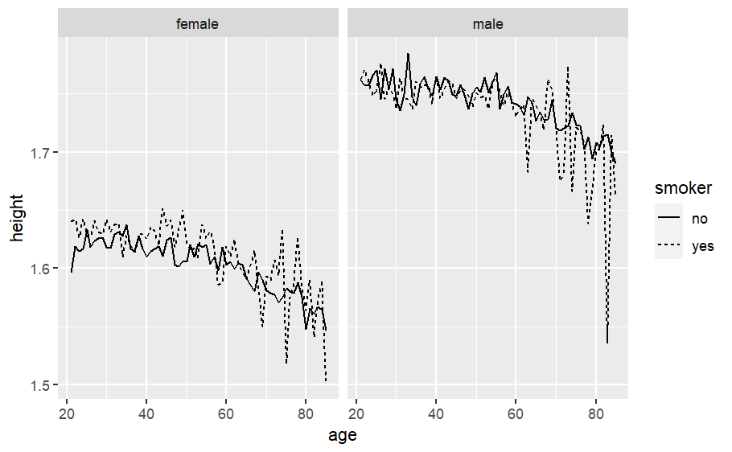

```r
Heights %>%
  ggplot(aes(x = age, y = height)) +
  geom_line(aes(linetype = smoker)) +
  facet_wrap( ~ sex)
```

## Remarks about faceting: `facet_grid()`

- `facet_grid()` allows control of row & column facets
- `facet_grid()` syntax:
  - row & column facets: `facet_grid(rows ~ cols)`
  - row facets only: `facet_grid( rows ~ . )` (note the required “`.`”)
  - column facets only: `facet_grid( ~ cols)` (no “`.`” this time)

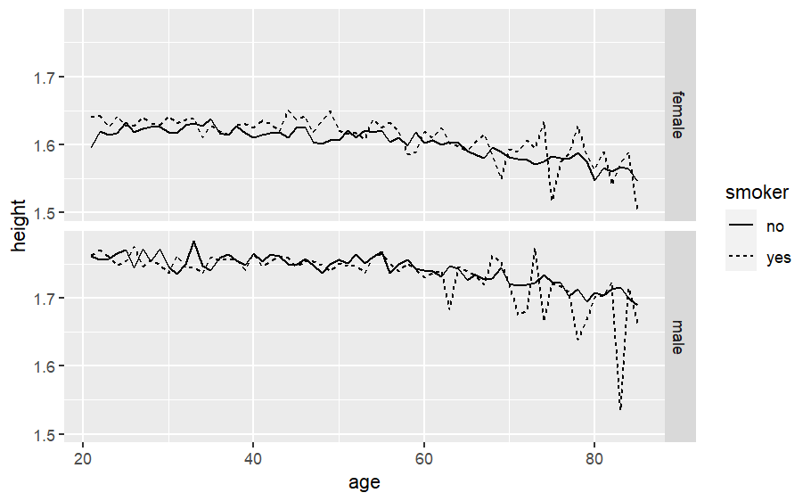

```r
Heights %>%
  ggplot(aes(x = age, y = height)) +
  geom_line(aes(linetype = smoker)) +
  facet_grid(sex ~ .)
```

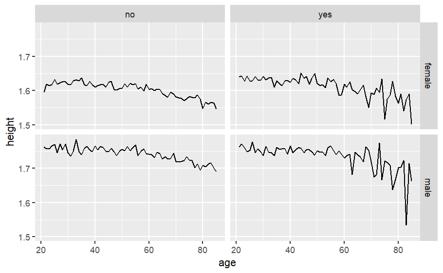

```r
Heights %>%
  ggplot(aes(x = age, y = height)) +
  geom_line() +
  facet_grid(sex ~ smoker)
```

## Difference between `color` and `fill`

```r
library(mosaicData)

head(CPS85)
```

|  | wage | educ | race | sex | hispanic | south | married | exper | union | age | sector |
| --- | --- | --- | --- | --- | --- | --- | --- | --- | --- | --- | --- |
| 1 | 9.0 | 10 | W | M | NH | NS | Married | 27 | Not | 43 | const |
| 2 | 5.5 | 12 | W | M | NH | NS | Married | 20 | Not | 38 | sales |
| 3 | 3.8 | 12 | W | F | NH | NS | Single | 4 | Not | 22 | sales |
| 4 | 10.5 | 12 | W | F | NH | NS | Married | 29 | Not | 47 | clerical |
| 5 | 15.0 | 12 | W | M | NH | NS | Married | 40 | Union | 58 | const |
| 6 | 9.0 | 16 | W | F | NH | NS | Married | 27 | Not | 49 | clerical |

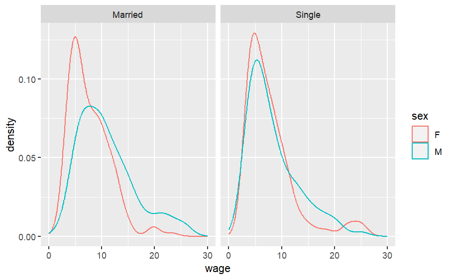

```r
CPS85 %>%
  ggplot() +
  geom_density(aes(x = wage, color = sex), alpha = 0.4)+
  facet_grid( ~ married) +
  xlim(0,30)
```

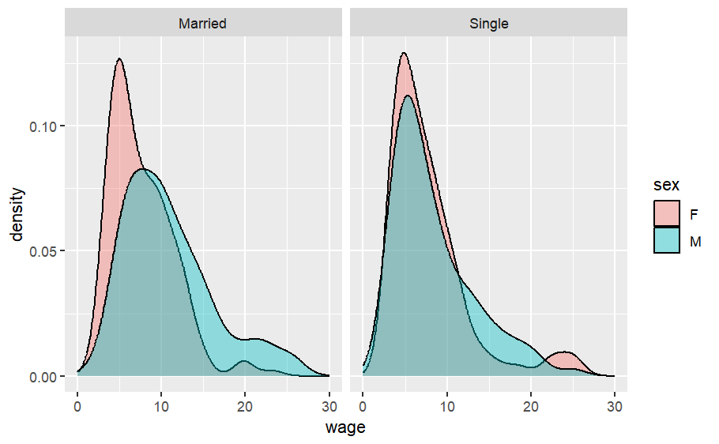

```r
CPS85 %>%
  ggplot() +
  geom_density(aes(x = wage, fill = sex), alpha = 0.4)+
  facet_grid( ~ married) +
  xlim(0,30)
```

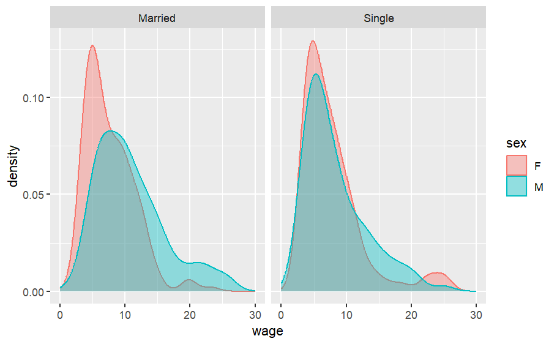

```r
CPS85 %>%
  ggplot() +
  geom_density(aes(x = wage, fill = sex, color = sex), alpha = 0.4)+
  facet_grid( ~ married) +
  xlim(0,30)
```

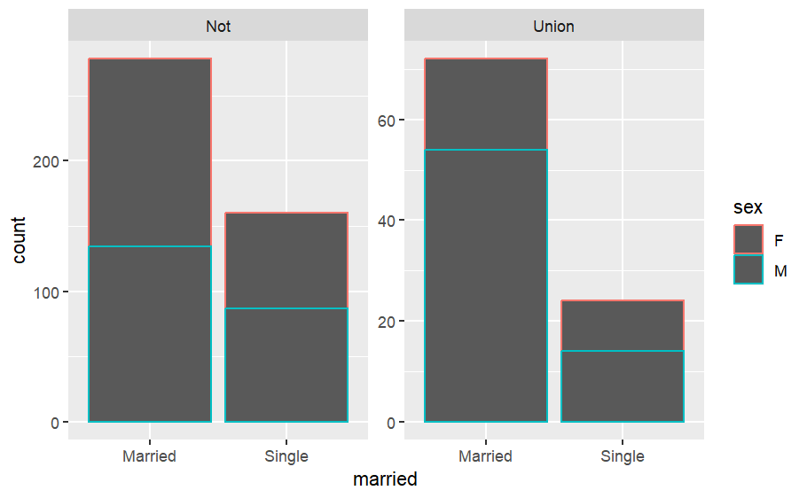

```r
CPS85%>%
  ggplot(aes(x = married, color = sex)) +
  geom_bar() +
  facet_wrap( ~ union, scales = "free")  #Note the scales here
```

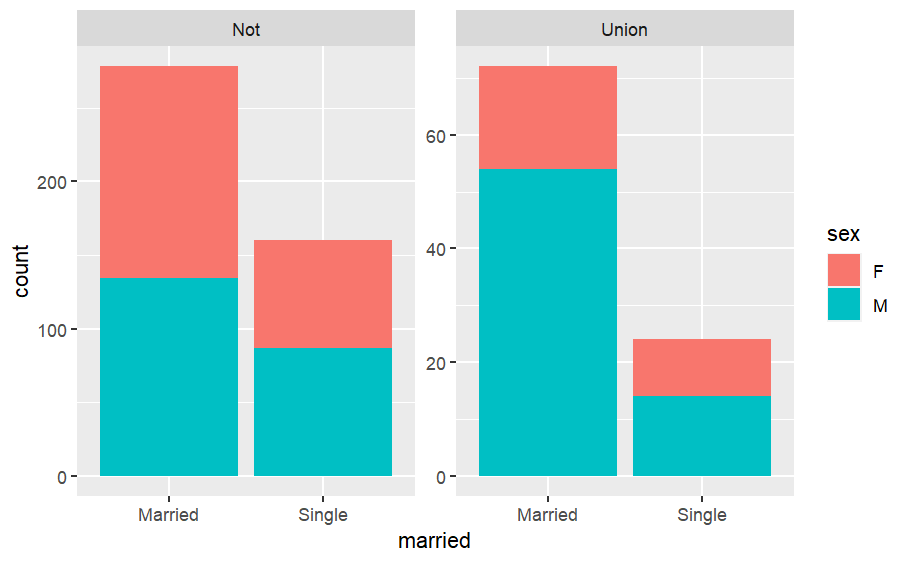

```r
CPS85%>%
  ggplot(aes(x = married, fill = sex)) +
  geom_bar()+
  facet_wrap( ~ union, scales = "free")  #Note the scales here
```

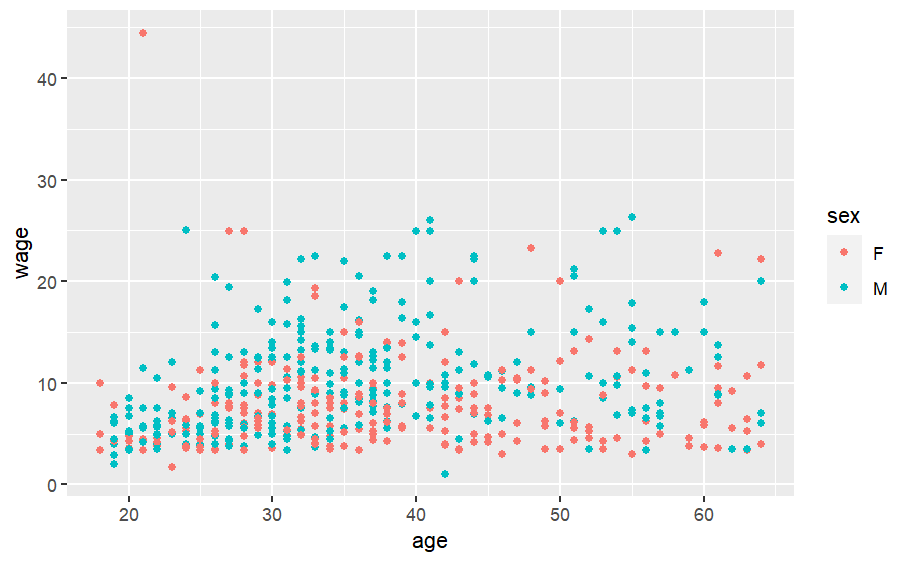

```r
CPS85%>%
  ggplot(aes(x = age, y = wage, color = sex)) +
  geom_point()
```

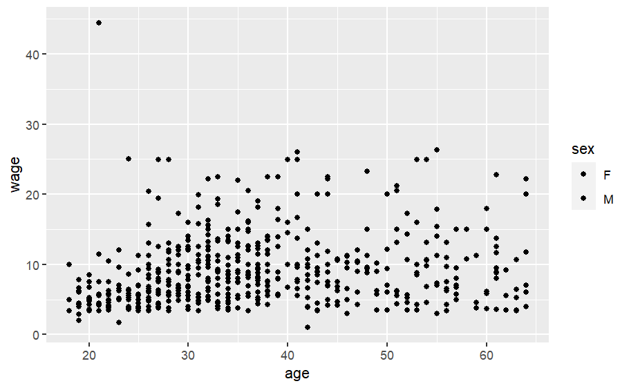

```r
CPS85%>%
  ggplot(aes(x = age, y = wage, fill = sex)) +  #fill does not work for points!
  geom_point()
```

```r
NA
NA
```

## Another Example using Diamonds Data

1. establish the frame
2. plot the glyphs (i.e., select a geom)
3. map the aesthetics
4. add labels and title
5. other features (e.g., alpha, sizing, etc)
6. Establish the Frame

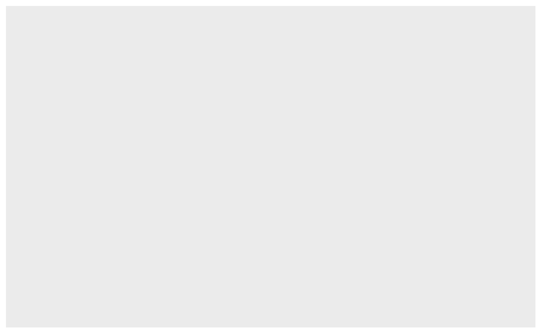

```r
ggplot(data = diamonds)
```

2. plot the glyphs (i.e., select a geom)

```r
ggplot(data = diamonds) +
  geom_point()
```

```
Error in `geom_point()`:
! Problem while setting up geom.
ℹ Error occurred in the 1st layer.
Caused by error in `compute_geom_1()`:
! `geom_point()` requires the following missing
  aesthetics: x and y
Backtrace:
  1. base (local) `<fn>`(x)
  2. ggplot2:::print.ggplot(x)
  4. ggplot2:::ggplot_build.ggplot(x)
  5. ggplot2:::by_layer(...)
 12. ggplot2 (local) f(l = layers[[i]], d = data[[i]])
 13. l$compute_geom_1(d)
 14. ggplot2 (local) compute_geom_1(..., self = self)
```

3. Map the aesthetics

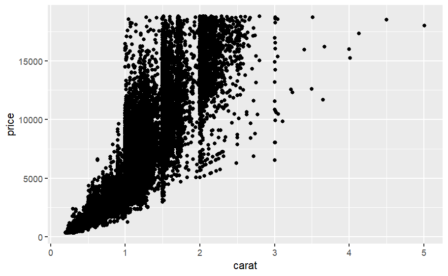

```r
ggplot(data = diamonds, aes(x = carat, y = price)) +
  geom_point()
```

4. Add Titles and Labels

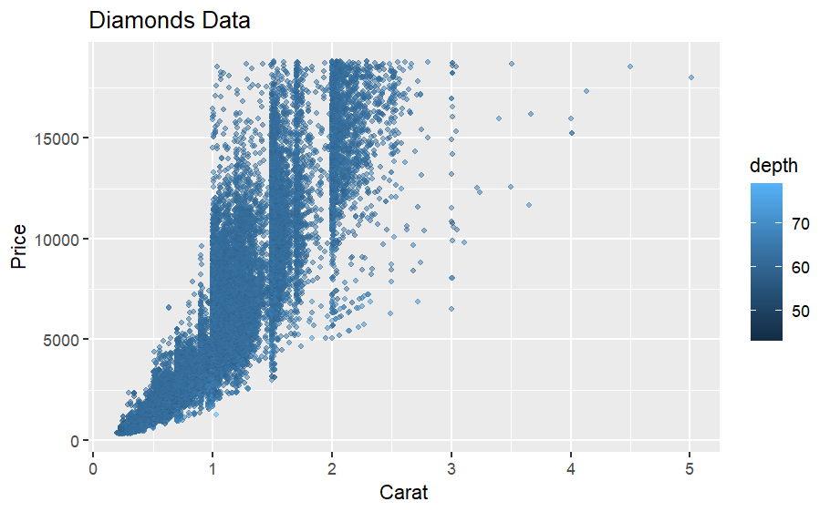

```r
ggplot(data = diamonds, aes(x = carat, y = price)) +
  geom_point(aes(color = depth), alpha = 0.5, size = 1) +
  ggtitle("Diamonds Data") +
  xlab("Carat") +
  ylab("Price")
```

5. Add additional features

Notice that I can have `aes` inside multiple statements. Notice that when I use constants (like `alpha = 0.3, size = 0.1`) they ARE NOT inside `aes`.

In general, variables go inside `aes` and constants go outside of it. (unless we are using facets then see previous materials.)

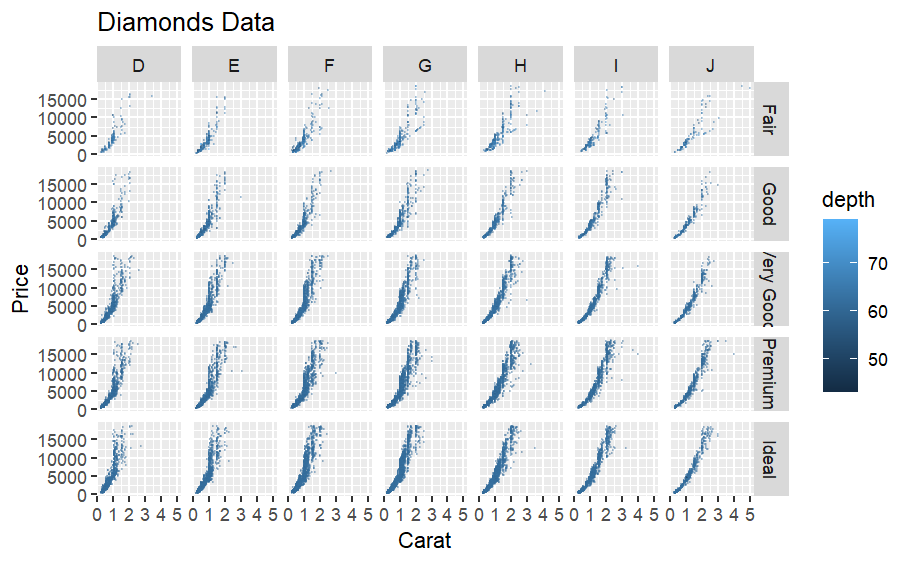

```r
ggplot(data = diamonds, aes(x = carat, y = price)) +
  geom_point(aes(colour = depth), alpha = 0.3, size = 0.1) +
  ggtitle("Diamonds Data") +
  xlab("Carat") +
  ylab("Price") +
  facet_grid( cut ~ color)
```

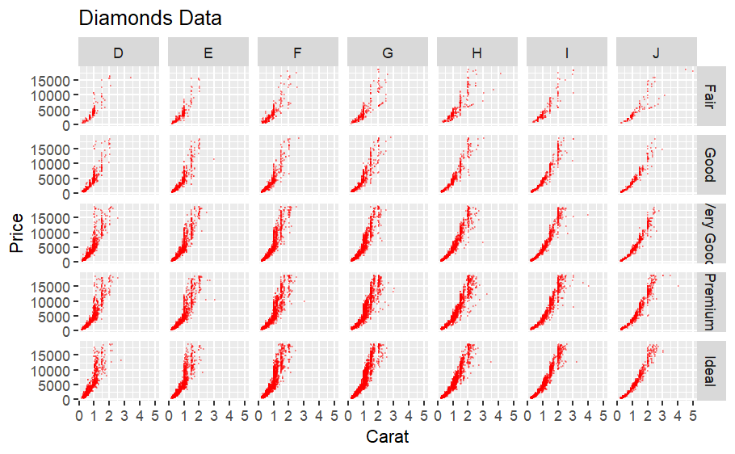

```r
ggplot(data = diamonds, aes(x = carat, y = price)) +
  geom_point(colour = "red", alpha = 0.3, size = 0.1) +
  ggtitle("Diamonds Data") +
  xlab("Carat") +
  ylab("Price") +
  facet_grid( cut ~ color)
```

## Side Note about placement of `aes`

`aes` can either go inside the `ggplot()` function, or inside the `geom_[chart]()` function itself, or both. The 3 following options create the same plots, but the code is slightly different.

```r
#option 1
ggplot(data = diamonds, ) +
  geom_point(aes(x = carat, y = price, color = clarity),
             alpha = 0.2,
             size = 1) +
  geom_smooth(method = "glm" ,
              formula = y ~ poly(x, 2),                     # y = b_0 + b_1 x + b_2 x^2 + e
              aes(x = carat, y = price),
              color = "red") +
  ylim(c(0, 20000))
```

[output not shown]

```r
#option 2
ggplot(data = diamonds, aes(x = carat, y = price, color = clarity)) +
  geom_point(alpha = 0.2,
             size = 1) +
  geom_smooth(method = "glm" ,
              formula = y ~ poly(x, 2),                     # y = b_0 + b_1 x + b_2 x^2 + e
              aes(x = carat, y = price),
              color = "red") +
  ylim(c(0, 20000))
```

[output not shown]

```r
#Option 3
ggplot(data = diamonds,  aes(x = carat, y = price) )+
  geom_point( aes(color = clarity),
              alpha = 0.2,
              size = 1) +
  geom_smooth(method = "glm" ,
              formula = y ~ poly(x, 2),                     # y = b_0 + b_1 x + b_2 x^2 + e
              color = "red") +
  ylim(c(0, 20000))
```

[output not shown]

## Additional resources for learning more about ggplot2

- Check out http://www.sthda.com/english/wiki/ggplot2-essentials

## Reminders about assignments (all due Friday July 21, 9:59 am)

- Activity: PopularNames
- Reading quiz DataComputing Ebook Chapters 10 and 11

## Suggested Reading before tomorrow’s class (July 20)

- DataComputing Ebook Chapter 12